# Project Part-3

Sai Pavan #R11778698,Rishidhar Rao #R11842808, Hemanth Reddy #R11842807

2022-12-04

# Part - 03

## *Perform a designed experiment to determine the effect of the available factors of Pin Elevation, Bungee Position, Release Angle, and Ball Type on distance in which a ball is thrown. Design this experiment as a single replicate of a* $2^{4}$ factorial design with the low and high level of the factors being as follows.

Pin Elevation - Position 1 (-1), Position 3 (+1);

Bungee Position - Position 2 (-1), Position 3 (+1);

Release Angle - $90^{0} (-1),\space 110^{0} (+1)$;

Ball Type - Yellow (-1), Red (+1).

### *a) Propose a data collection layout with a randomized run order.*

### The factorial design each factor with two levels, complete random design and single replicate.

### **Layout generation**

```r
library(agricolae)
trts<-c(2,2,2,2)
design.ab(trt=trts,r=1,design="crd",seed=25586)
```

```
## $parameters
## $parameters$design
## [1] "factorial"
##
## $parameters$trt
##  [1] "1 1 1 1" "1 1 1 2" "1 1 2 1" "1 1 2 2" "1 2 1 1" "1 2 1 2" "1 2 2 1"
##  [8] "1 2 2 2" "2 1 1 1" "2 1 1 2" "2 1 2 1" "2 1 2 2" "2 2 1 1" "2 2 1 2"
## [15] "2 2 2 1" "2 2 2 2"
##
## $parameters$r
##  [1] 1 1 1 1 1 1 1 1 1 1 1 1 1 1 1 1
##
## $parameters$serie
## [1] 2
##
## $parameters$seed
## [1] 25586
##
## $parameters$kinds
## [1] "Super-Duper"
##
## $parameters[[7]]
## [1] TRUE
##
## $parameters$applied
## [1] "crd"
##
##
## $book
##    plots r A B C D
## 1    101 1 1 2 1 2
## 2    102 1 2 1 2 2
## 3    103 1 2 2 2 2
## 4    104 1 2 2 1 1
## 5    105 1 2 1 1 2
## 6    106 1 2 1 2 1
## 7    107 1 1 1 1 1
## 8    108 1 1 1 2 2
## 9    109 1 1 1 1 2
## 10   110 1 1 2 2 1
## 11   111 1 1 2 1 1
## 12   112 1 2 2 2 1
## 13   113 1 2 1 1 1
## 14   114 1 2 2 1 2
## 15   115 1 1 2 2 2
## 16   116 1 1 1 2 1
```

A: Ball Type - Yellow (-1), Red (1)

B: Release Angle - $90^{0} (-1), 110^{0} (+1)$

C: Bungee Position - Position 2 (-1), Position 3 (+1)

D: Pin Elevation - Position 1 (-1), Position 3 (+1)

### *b) Collect data and record observations*

### **Data Entry**

```r
library("readxl")
Fdata3<-read_excel("C:/Users/Saipa/OneDrive/Desktop/DOE/Projectdata3.xlsx")
print(Fdata3)
```

```
## # A tibble: 16 x 5
##    `Ball Type` `Release Angle` `Bungee Position` `Pin Elevation`   Obs
##          <dbl>           <dbl>             <dbl>           <dbl> <dbl>
##  1          -1               1                -1               1    28
##  2           1              -1                 1               1    23
##  3           1               1                 1               1    19
##  4           1               1                -1              -1    54
##  5           1              -1                -1               1    27
##  6           1              -1                 1              -1    54
##  7          -1              -1                -1              -1    37
##  8          -1              -1                 1               1    28
##  9          -1              -1                -1               1    33
## 10          -1               1                 1              -1    52
## 11          -1               1                -1              -1    56
## 12           1               1                 1              -1    42
## 13           1              -1                -1              -1    40
## 14           1               1                -1               1    20
## 15          -1               1                 1               1    15
## 16          -1              -1                 1              -1    43
```

```r
#colnames(Fdata3)<-c("A","B","C","D","Obs")
#print(Fdata3)
A<-Fdata3$`Ball Type`
B<-Fdata3$`Release Angle`
C<-Fdata3$`Bungee Position`
D<-Fdata3$`Pin Elevation`
Obs<-Fdata3$Obs
```

### *c) State model equation and determine what factors/interactions appear to be significant (show any plots that were used in making this determination).*

### **Model equation.**

$y_{ijklm}= \mu + \alpha_i + \beta_j + \gamma_k + \delta_l + \alpha\beta_{ij} + \alpha\gamma_{ik} + \alpha\delta_{il} + \beta\gamma_{jk} + \beta\delta_{jl} + \gamma\delta_{kl} + \alpha\beta\gamma_{ijk} + \alpha\beta\delta_{ijl} + \beta\gamma\delta_{jkl} + \alpha\beta\gamma\delta_{ijkl} + \epsilon_{ijklm}$

where; $\mu$: Grand mean

### Controllable Error

$\alpha_i, \beta_j, \gamma_k, \delta_l$: Main effects of factors A, B, C and D respectively

$\alpha\beta_{ij}, \alpha\gamma_{ik}, \alpha\delta_{il}, \beta\gamma_{jk}, \beta\delta_{jl}, \gamma\delta_{kl}, \alpha\beta\gamma_{ijk}, \alpha\beta\delta_{ijl}, \beta\gamma\delta_{jkl}, \alpha\beta\gamma\delta_{ijkl}$: This are the two factor, three factor and four factor interactions.

### Uncontrollable Error

$\epsilon_{ijklm}$: Random error which is distributed normal (0,1).

### **Finding the significant factors**

### For the single replicate of this design we can find the factors and terms which are significantly differing from the Half-Normal Plot.

```r
library(DoE.base)
fmodel<-aov(Obs~A*B*C*D)
coef(fmodel)
```

```
## (Intercept)           A           B           C           D         A:B
##     35.6875     -0.8125      0.0625     -1.1875    -11.5625     -1.1875
##         A:C         B:C         A:D         B:D         C:D       A:B:C
##      0.8125     -2.5625     -1.0625     -3.6875     -1.6875     -0.3125
##       A:B:D       A:C:D       B:C:D     A:B:C:D
##      2.0625      0.8125      1.9375      1.6875
```

```r
summary(fmodel)
```

```
##             Df Sum Sq Mean Sq
## A            1   10.6    10.6
## B            1    0.1     0.1
## C            1   22.6    22.6
## D            1 2139.1  2139.1
## A:B          1   22.6    22.6
## A:C          1   10.6    10.6
## B:C          1  105.1   105.1
## A:D          1   18.1    18.1
## B:D          1  217.6   217.6
## C:D          1   45.6    45.6
## A:B:C        1    1.6     1.6
## A:B:D        1   68.1    68.1
## A:C:D        1   10.6    10.6
## B:C:D        1   60.1    60.1
## A:B:C:D      1   45.6    45.6
```

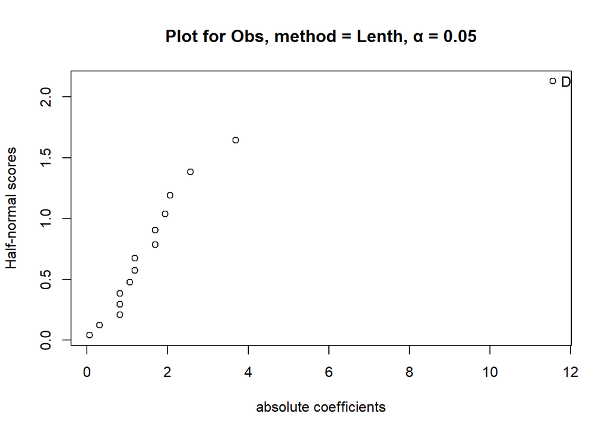

```r
halfnormal(fmodel)
```

$\underline{Comments}$:From the half normal plot ,we got only Pin Elevation(D) as the significant factor. This factor are used for the further analysis and rest of the factors are considered as error factors.

### *d) After using insignificant factors/interactions to create an error term, perform ANOVA to determine a final model equation using an alpha = 0.05.*

### **FINAL ANOVA MODEL.**

```r
fmodel2<-aov(Obs~D)
summary(fmodel2)
```

```
##             Df Sum Sq Mean Sq F value   Pr(>F)
## D            1 2139.1  2139.1   46.91 7.94e-06 ***
## Residuals   14  638.4    45.6
## ---
## Signif. codes:  0 '***' 0.001 '**' 0.01 '*' 0.05 '.' 0.1 ' ' 1
```

$\underline{Comments}$: After removing all insignificant terms from the model and we can say that main effect D is only significantly differing at $\alpha = 0.05$ as we got $P-value = 7.94e^{-06}$ .

$\underline{Conclusion}$: The analysis gave us that, The distance to which the particular type of ball is thrown is depending only on Pin Elevation only. Remaining all the factors are just considered as error factors i.e they are not effecting the distance thrown(insignificant terms or factors).

## Source Code

```r
# Layout generation
library(agricolae)
trts<-c(2,2,2,2)
design.ab(trt=trts,r=1,design="crd",seed=25586)

# Data Entry
library("readxl")
Fdata3<-read_excel("C:/Users/Saipa/OneDrive/Desktop/DOE/Projectdata3.xlsx")
print(Fdata3)
#colnames(Fdata3)<-c("A","B","C","D","Obs")
#print(Fdata3)
A<-Fdata3$`Ball Type`
B<-Fdata3$`Release Angle`
C<-Fdata3$`Bungee Position`
D<-Fdata3$`Pin Elevation`
Obs<-Fdata3$Obs

# Checking For Significant Factors
library(DoE.base)
fmodel<-aov(Obs~A*B*C*D)
coef(fmodel)
summary(fmodel)
halfnormal(fmodel)

# Final Model
fmodel2<-aov(Obs~D)
summary(fmodel2)
```